# U.S. Jail Population Analysis

Hanjiang Xu

2022-11-21

## Abstract

This report contains six sections working with the incarceration data set collected by the Vera Institute. Sections include an introduction, a data summary, and four charts. Each section will answer questions regarding the potential inequalities in the U.S. prison system.

## 1. Introduction

To start this report, it is necessary to discuss why we care about this data. Vera Institute is powered by researchers and advocates working to transform the criminal legal system till it is fair for all. It is safe to say that no system in this world is prefect, including the U.S. prison system. Issues such as criminalization and racial disparities are serious problems that the society should look into. In this case, this report is going to run a series of data analysis and data visualization that hopefully displays the inequalities within the U.S. prison system. The direct stakeholder of this analysis report would be the U.S. prison system. The institutions relates to the U.S. prison would be able to improve their system based on the feedback. The indirect stakeholders of this report would be individuals in incarceration and individuals who have loved one in incarceration. Following are questions that would be answered in the section 3, 4, 5, 6 of the report.

- What can the graphs tell about U.S. prison population?
- How does the growth of jail population relates to its region?
- What can the graphs show about the difference between female and male jail population?

## 2. Data Summary

For this data summary, I have picked three values to calculated: total jail population(total_jail_pop), female jail population(female_jail_pop) and black jail population(black_jail_pop). This data summary is going to answer three questions: the average value of each year, the place with highest/lowest values, and the growth of each value in the past 20 years.

Question 1: The average value of variables across all the counties (in a given year)

- Following is a section of the data table. I intentionally selected data from 2000 to 2010 ro answer out questions better. In the data table, we can see that the total jail population is gradually rising each year, which is not too surprising. Yet if we compare the increase of female jail population and black jail population, we can see that the black jail population was rising much faster. The black jail population have increase around 11.76 while female only increased 7.28 with a decline in 2009. This information disclose that there might be racial inequities in prison where the possibility of a black individual getting arrested is much higher.

```
## # A tibble: 10 × 4
##     year average_total_jail_pop average_female_jail_pop average_black_jail_pop
##    <int>                  <dbl>                   <dbl>                  <dbl>
##  1  2000                   201.                    23.0                   81.7
##  2  2001                   204.                    24.0                   82.5
##  3  2002                   212.                    25.2                   85.1
##  4  2003                   221.                    26.9                   87.0
##  5  2004                   229.                    28.7                   89.1
##  6  2005                   235.                    30.3                   91.0
##  7  2006                   243.                    31.3                   92.8
##  8  2007                   245.                    31.6                   94.2
##  9  2008                   248.                    31.5                   95.3
## 10  2009                   246.                    30.2                   93.5
```

Question 2: Places with highest/lowest values

- Since our data is calculated based on years, and each variable will vary based on each year, I will be selecting one specific years to calculation the highest and lowest: 2018, which is also the most recent data our date set includes. First of all, following are the county names for highest in each variable:

```
## [1] "Los Angeles County"
```

```
## [1] "Los Angeles County"
```

```
## [1] "Los Angeles County"
```

- Following are the county names in lowest of each variable. I will only be showing the first three county names since there are multiple counties for each variable. To be more specific, all of the lowest county have a value of zero in each variable.

```
## [1] "Caldwell County"  "Lyon County"      "Big Stone County"
```

```
## [1] "Sumter County"          "Aleutians East Borough" "Dillingham Census Area"
```

```
## [1] "Bethel Census Area"     "Bristol Bay Borough"    "Dillingham Census Area"
```

- It is surprising to see that the Los Angeles County has the highest value in all three variables. However, as we can see with the lowest variables, there are 289 counties that does not have any black individuals in jail. Yet comparing with the rising numbers of black jail populations, it seemingly does not match. One of my hypothesis is that the rise of black jail population might be centered around regions such as the Los Angele county, which disclose that the prison might have inequality based on regions.

Question 3: Change in values for the last 20 years

```
##   all_total_jail_pop all_female_jail_pop all_black_jail_pop
## 1           143535.9            38415.19            1463.52
```

From this calculation we can see that for the last 20 years, there has been a incredible increase in both total jail population and all female jail population, yet black jail population did not have a such high increase. However, this data seems to contrast with the findings from the findings in question one where black jail population had a higher increase than female jail population. One of the hypothesis for this is that many individuals are released within the past 20 years since i only calculated with the data from 1998 and 2018.

## 3. Growth of the U.S. Prison Population

Following is the graph of the growth of the U.S. prison population from 1970 to 2018.

- Question: What can the graphs tell about U.S. prison population?
  - In the following graph, we can see that the growth of the prison population is increasing gradually from 1970 to 2018. The graph did not show any decline which means that the number f individuals in jail have not decreased from 1970 to 2018. This data shows a rather concerning fact that more and more people are in jail each year.

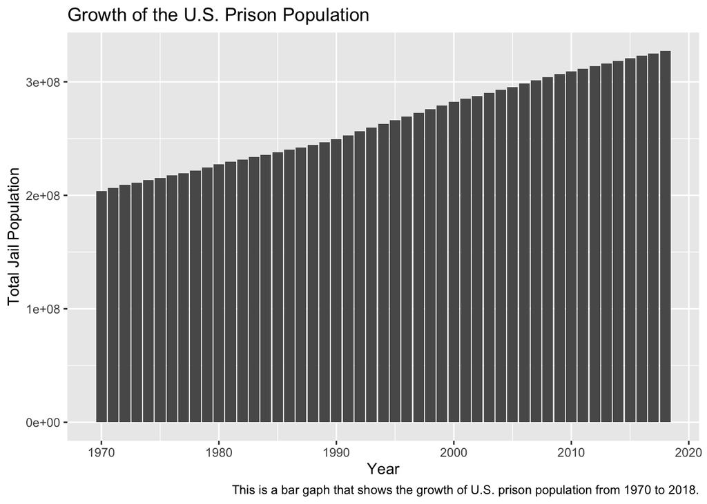

## 4. Growth of Prison Population by State

Following is the graph of the growth of the U.S prison population of Alabama, California, Oregon and New York.

- Question: How does the growth of jail population relates to its region?
  - To answer this question, we have to consider the popularity and the urbanization of the state. It is clear that California and New York has a much higher jail population than Oregon and Alabama. The high prison population matches with my previous finding in section 2, where Los Angeles has the highest number in all three variable examined. California and New York are considered as some of the most popular and urbanized states in America, and it also has a much higher overall population. In this case, one of my hypothesis is that there might be a positive correlation between jail population and the urbanization of the state.

[figure not shown]

## 5. Female v.s Male Jail Population of 2018

Following is a graph that displaces the number of male compare to female jail population. As displayed below, the blue bars represents male while the purple bars represent female. This graph only indicates number from 2018 of each state.

- Question: What can the graphs show about the difference between female and male jail population?
  - Looking carefully st this graph, it is clear that female jail population is overall much lower than male population. California and Texas might have a significant higher female population than other states, but they also have a much higher male population. In this case, it’s safe to say that most of the jail in each states are dominated by male.

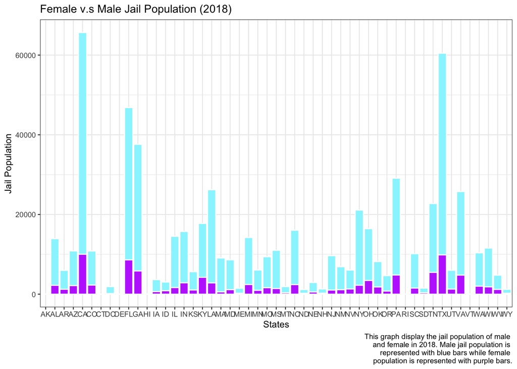

## 6. Map of Black Jail Population Ratio of 2018

Following is a map that displays the black jail population ratio of 2018 in the U.S. Darker blue represents higher ratio while lighter blue represents lower ratio.

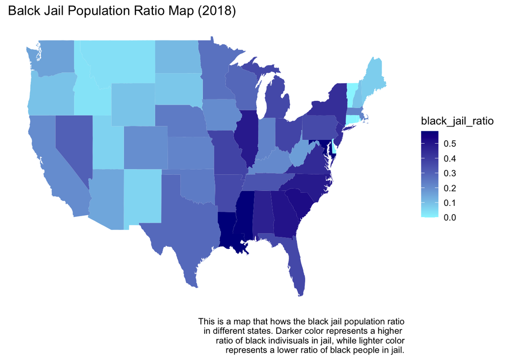